# Risk Factor Analysis

## Outcome Variable

**Outcome Variable:** ever_stunted

## Predictor Variables

**Intervention Variable:** predexfd6

**Adjustment Set:**

unadjusted

## Stratifying Variables

The analysis was stratified on these variable(s):

- agecat
- studyid
- country

## Data Summary

| agecat | studyid | country | predexfd6 | ever_stunted | n_cell | n |
| --- | --- | --- | --- | --- | --- | --- |
| 0-6 months | ki0047075b-MAL-ED | BANGLADESH | 0 | 0 | 92 | 238 |
| 0-6 months | ki0047075b-MAL-ED | BANGLADESH | 0 | 1 | 21 | 238 |
| 0-6 months | ki0047075b-MAL-ED | BANGLADESH | 1 | 0 | 106 | 238 |
| 0-6 months | ki0047075b-MAL-ED | BANGLADESH | 1 | 1 | 19 | 238 |
| 0-6 months | ki0047075b-MAL-ED | BRAZIL | 0 | 0 | 159 | 212 |
| 0-6 months | ki0047075b-MAL-ED | BRAZIL | 0 | 1 | 17 | 212 |
| 0-6 months | ki0047075b-MAL-ED | BRAZIL | 1 | 0 | 32 | 212 |
| 0-6 months | ki0047075b-MAL-ED | BRAZIL | 1 | 1 | 4 | 212 |
| 0-6 months | ki0047075b-MAL-ED | INDIA | 0 | 0 | 181 | 234 |
| 0-6 months | ki0047075b-MAL-ED | INDIA | 0 | 1 | 34 | 234 |
| 0-6 months | ki0047075b-MAL-ED | INDIA | 1 | 0 | 13 | 234 |
| 0-6 months | ki0047075b-MAL-ED | INDIA | 1 | 1 | 6 | 234 |
| 0-6 months | ki0047075b-MAL-ED | NEPAL | 0 | 0 | 181 | 235 |
| 0-6 months | ki0047075b-MAL-ED | NEPAL | 0 | 1 | 25 | 235 |
| 0-6 months | ki0047075b-MAL-ED | NEPAL | 1 | 0 | 27 | 235 |
| 0-6 months | ki0047075b-MAL-ED | NEPAL | 1 | 1 | 2 | 235 |
| 0-6 months | ki0047075b-MAL-ED | PERU | 0 | 0 | 135 | 270 |
| 0-6 months | ki0047075b-MAL-ED | PERU | 0 | 1 | 21 | 270 |
| 0-6 months | ki0047075b-MAL-ED | PERU | 1 | 0 | 103 | 270 |
| 0-6 months | ki0047075b-MAL-ED | PERU | 1 | 1 | 11 | 270 |
| 0-6 months | ki0047075b-MAL-ED | SOUTH AFRICA | 0 | 0 | 221 | 248 |
| 0-6 months | ki0047075b-MAL-ED | SOUTH AFRICA | 0 | 1 | 24 | 248 |
| 0-6 months | ki0047075b-MAL-ED | SOUTH AFRICA | 1 | 0 | 1 | 248 |
| 0-6 months | ki0047075b-MAL-ED | SOUTH AFRICA | 1 | 1 | 2 | 248 |
| 0-6 months | ki0047075b-MAL-ED | TANZANIA, UNITED REPUBLIC OF | 0 | 0 | 208 | 248 |
| 0-6 months | ki0047075b-MAL-ED | TANZANIA, UNITED REPUBLIC OF | 0 | 1 | 38 | 248 |
| 0-6 months | ki0047075b-MAL-ED | TANZANIA, UNITED REPUBLIC OF | 1 | 0 | 2 | 248 |
| 0-6 months | ki0047075b-MAL-ED | TANZANIA, UNITED REPUBLIC OF | 1 | 1 | 0 | 248 |
| 0-6 months | ki1000108-CMC-V-BCS-2002 | INDIA | 1 | 0 | 14 | 19 |
| 0-6 months | ki1000108-CMC-V-BCS-2002 | INDIA | 1 | 1 | 5 | 19 |

[output cut: 168 more lines]

The following strata were considered:

- agecat: 0-24 months, studyid: ki0047075b-MAL-ED, country: BANGLADESH
- agecat: 0-24 months, studyid: ki0047075b-MAL-ED, country: BRAZIL
- agecat: 0-24 months, studyid: ki0047075b-MAL-ED, country: INDIA
- agecat: 0-24 months, studyid: ki0047075b-MAL-ED, country: NEPAL
- agecat: 0-24 months, studyid: ki0047075b-MAL-ED, country: PERU
- agecat: 0-24 months, studyid: ki0047075b-MAL-ED, country: SOUTH AFRICA
- agecat: 0-24 months, studyid: ki0047075b-MAL-ED, country: TANZANIA, UNITED REPUBLIC OF
- agecat: 0-24 months, studyid: ki1000108-CMC-V-BCS-2002, country: INDIA
- agecat: 0-24 months, studyid: ki1000108-IRC, country: INDIA
- agecat: 0-24 months, studyid: ki1000109-EE, country: PAKISTAN
- agecat: 0-24 months, studyid: ki1000304b-SAS-CompFeed, country: INDIA
- agecat: 0-24 months, studyid: ki1000304b-SAS-FoodSuppl, country: INDIA
- agecat: 0-24 months, studyid: ki1017093b-PROVIDE, country: BANGLADESH
- agecat: 0-24 months, studyid: ki1101329-Keneba, country: GAMBIA
- agecat: 0-24 months, studyid: ki1113344-GMS-Nepal, country: NEPAL
- agecat: 0-24 months, studyid: ki1148112-LCNI-5, country: MALAWI
- agecat: 0-24 months, studyid: kiGH5241-JiVitA-3, country: BANGLADESH
- agecat: 0-24 months, studyid: kiGH5241-JiVitA-4, country: BANGLADESH
- agecat: 0-6 months, studyid: ki0047075b-MAL-ED, country: BANGLADESH
- agecat: 0-6 months, studyid: ki0047075b-MAL-ED, country: BRAZIL
- agecat: 0-6 months, studyid: ki0047075b-MAL-ED, country: INDIA
- agecat: 0-6 months, studyid: ki0047075b-MAL-ED, country: NEPAL
- agecat: 0-6 months, studyid: ki0047075b-MAL-ED, country: PERU
- agecat: 0-6 months, studyid: ki0047075b-MAL-ED, country: SOUTH AFRICA
- agecat: 0-6 months, studyid: ki0047075b-MAL-ED, country: TANZANIA, UNITED REPUBLIC OF
- agecat: 0-6 months, studyid: ki1000108-CMC-V-BCS-2002, country: INDIA
- agecat: 0-6 months, studyid: ki1000108-IRC, country: INDIA
- agecat: 0-6 months, studyid: ki1000109-EE, country: PAKISTAN
- agecat: 0-6 months, studyid: ki1000304b-SAS-CompFeed, country: INDIA
- agecat: 0-6 months, studyid: ki1000304b-SAS-FoodSuppl, country: INDIA
- agecat: 0-6 months, studyid: ki1017093b-PROVIDE, country: BANGLADESH
- agecat: 0-6 months, studyid: ki1101329-Keneba, country: GAMBIA
- agecat: 0-6 months, studyid: ki1113344-GMS-Nepal, country: NEPAL
- agecat: 0-6 months, studyid: ki1148112-LCNI-5, country: MALAWI
- agecat: 0-6 months, studyid: kiGH5241-JiVitA-3, country: BANGLADESH
- agecat: 0-6 months, studyid: kiGH5241-JiVitA-4, country: BANGLADESH
- agecat: 6-24 months, studyid: ki0047075b-MAL-ED, country: BANGLADESH
- agecat: 6-24 months, studyid: ki0047075b-MAL-ED, country: BRAZIL
- agecat: 6-24 months, studyid: ki0047075b-MAL-ED, country: INDIA
- agecat: 6-24 months, studyid: ki0047075b-MAL-ED, country: NEPAL
- agecat: 6-24 months, studyid: ki0047075b-MAL-ED, country: PERU
- agecat: 6-24 months, studyid: ki0047075b-MAL-ED, country: SOUTH AFRICA
- agecat: 6-24 months, studyid: ki0047075b-MAL-ED, country: TANZANIA, UNITED REPUBLIC OF
- agecat: 6-24 months, studyid: ki1000108-CMC-V-BCS-2002, country: INDIA
- agecat: 6-24 months, studyid: ki1000108-IRC, country: INDIA
- agecat: 6-24 months, studyid: ki1000109-EE, country: PAKISTAN
- agecat: 6-24 months, studyid: ki1000304b-SAS-CompFeed, country: INDIA
- agecat: 6-24 months, studyid: ki1000304b-SAS-FoodSuppl, country: INDIA
- agecat: 6-24 months, studyid: ki1017093b-PROVIDE, country: BANGLADESH
- agecat: 6-24 months, studyid: ki1101329-Keneba, country: GAMBIA
- agecat: 6-24 months, studyid: ki1113344-GMS-Nepal, country: NEPAL
- agecat: 6-24 months, studyid: ki1148112-LCNI-5, country: MALAWI
- agecat: 6-24 months, studyid: kiGH5241-JiVitA-3, country: BANGLADESH
- agecat: 6-24 months, studyid: kiGH5241-JiVitA-4, country: BANGLADESH

### Dropped Strata

Some strata were dropped due to rare outcomes:

- agecat: 0-6 months, studyid: ki0047075b-MAL-ED, country: BRAZIL
- agecat: 0-6 months, studyid: ki0047075b-MAL-ED, country: NEPAL
- agecat: 0-6 months, studyid: ki0047075b-MAL-ED, country: SOUTH AFRICA
- agecat: 0-6 months, studyid: ki0047075b-MAL-ED, country: TANZANIA, UNITED REPUBLIC OF
- agecat: 0-6 months, studyid: ki1000108-IRC, country: INDIA
- agecat: 6-24 months, studyid: ki0047075b-MAL-ED, country: BRAZIL
- agecat: 6-24 months, studyid: ki0047075b-MAL-ED, country: NEPAL
- agecat: 6-24 months, studyid: ki0047075b-MAL-ED, country: SOUTH AFRICA
- agecat: 6-24 months, studyid: ki0047075b-MAL-ED, country: TANZANIA, UNITED REPUBLIC OF
- agecat: 6-24 months, studyid: ki1000108-IRC, country: INDIA
- agecat: 6-24 months, studyid: ki1000304b-SAS-CompFeed, country: INDIA
- agecat: 0-24 months, studyid: ki0047075b-MAL-ED, country: SOUTH AFRICA
- agecat: 0-24 months, studyid: ki0047075b-MAL-ED, country: TANZANIA, UNITED REPUBLIC OF

## Methods Detail

We’re interested in the causal parameters $E[Y_a]$ for all values of $a \in \mathcal{A}$. These parameters represent the mean outcome if, possibly contrary to fact, we intervened to set all units to have $A=a$. Under the randomization and positivity assumptions, these are identified by the statistical parameters $\psi_a=E_W[E_{Y|A,W}(Y|A=a,W)]$. In addition, we’re interested in the mean of $Y$, $E[Y]$ under no intervention (the observed mean). We will estimate these parameters by using SuperLearner to fit the relevant likelihood factors – $E_{Y|A,W}(Y|A=a,W)$ and $p(A=a|W)$, and then updating our likelihood fit using a joint TMLE.

For unadjusted analyses ($W=\{\}$), initial likelihoods were estimated using Lrnr_glm to estimate the simple $E(Y|A)$ and Lrnr_mean to estimate $p(A)$. For adjusted analyses, a small library containing Lrnr_glmnet, Lrnr_xgboost, and Lrnr_mean was used.

Having estimated these parameters, we will then use the delta method to estimate relative risks and attributable risks relative to a prespecified baseline level of $A$.

[output not shown]

# Results Detail

## Results Plots

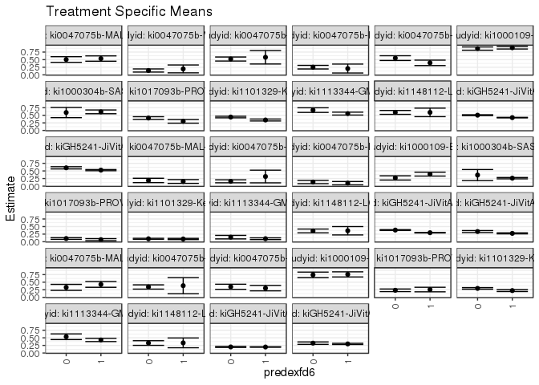

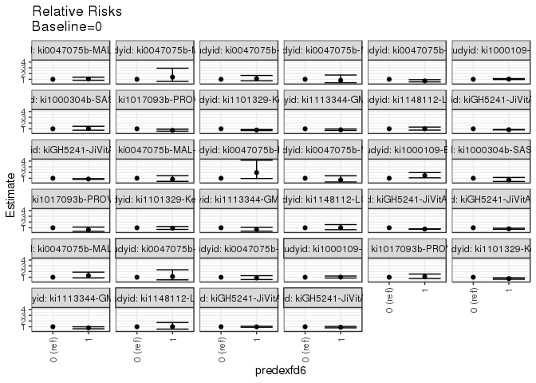

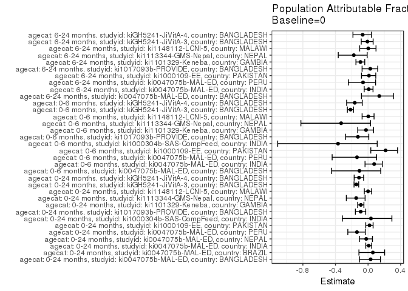

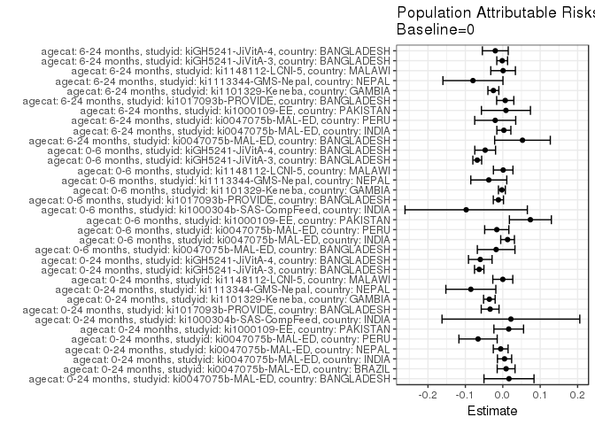

## Results Table

### Parameter: TSM

| agecat | studyid | country | intervention_level | baseline_level | estimate | ci_lower | ci_upper |
| --- | --- | --- | --- | --- | --- | --- | --- |
| 0-24 months | ki0047075b-MAL-ED | BANGLADESH | 0 | NA | 0.5044248 | 0.4120452 | 0.5968044 |
| 0-24 months | ki0047075b-MAL-ED | BANGLADESH | 1 | NA | 0.5360000 | 0.4483910 | 0.6236090 |
| 0-24 months | ki0047075b-MAL-ED | BRAZIL | 0 | NA | 0.1420455 | 0.0903486 | 0.1937423 |
| 0-24 months | ki0047075b-MAL-ED | BRAZIL | 1 | NA | 0.1944444 | 0.0648552 | 0.3240337 |
| 0-24 months | ki0047075b-MAL-ED | INDIA | 0 | NA | 0.5209302 | 0.4540115 | 0.5878490 |
| 0-24 months | ki0047075b-MAL-ED | INDIA | 1 | NA | 0.5789474 | 0.3564684 | 0.8014264 |
| 0-24 months | ki0047075b-MAL-ED | NEPAL | 0 | NA | 0.2524272 | 0.1929795 | 0.3118749 |
| 0-24 months | ki0047075b-MAL-ED | NEPAL | 1 | NA | 0.2068966 | 0.0591502 | 0.3546429 |
| 0-24 months | ki0047075b-MAL-ED | PERU | 0 | NA | 0.5512821 | 0.4730895 | 0.6294746 |
| 0-24 months | ki0047075b-MAL-ED | PERU | 1 | NA | 0.3947368 | 0.3048435 | 0.4846301 |
| 0-24 months | ki1000109-EE | PAKISTAN | 0 | NA | 0.8653846 | 0.8117542 | 0.9190151 |
| 0-24 months | ki1000109-EE | PAKISTAN | 1 | NA | 0.8923767 | 0.8516483 | 0.9331050 |
| 0-24 months | ki1000304b-SAS-CompFeed | INDIA | 0 | NA | 0.5909091 | 0.4229580 | 0.7588602 |
| 0-24 months | ki1000304b-SAS-CompFeed | INDIA | 1 | NA | 0.6137441 | 0.5514348 | 0.6760534 |
| 0-24 months | ki1017093b-PROVIDE | BANGLADESH | 0 | NA | 0.4095634 | 0.3655856 | 0.4535412 |
| 0-24 months | ki1017093b-PROVIDE | BANGLADESH | 1 | NA | 0.3013699 | 0.2405550 | 0.3621848 |
| 0-24 months | ki1101329-Keneba | GAMBIA | 0 | NA | 0.4421576 | 0.4162197 | 0.4680954 |
| 0-24 months | ki1101329-Keneba | GAMBIA | 1 | NA | 0.3450363 | 0.3126101 | 0.3774625 |
| 0-24 months | ki1113344-GMS-Nepal | NEPAL | 0 | NA | 0.6712329 | 0.5949658 | 0.7475000 |
| 0-24 months | ki1113344-GMS-Nepal | NEPAL | 1 | NA | 0.5560859 | 0.5084707 | 0.6037012 |
| 0-24 months | ki1148112-LCNI-5 | MALAWI | 0 | NA | 0.5955556 | 0.5313094 | 0.6598017 |
| 0-24 months | ki1148112-LCNI-5 | MALAWI | 1 | NA | 0.5957447 | 0.4551862 | 0.7363031 |
| 0-24 months | kiGH5241-JiVitA-3 | BANGLADESH | 0 | NA | 0.5035671 | 0.4892503 | 0.5178838 |
| 0-24 months | kiGH5241-JiVitA-3 | BANGLADESH | 1 | NA | 0.4231177 | 0.4146378 | 0.4315975 |
| 0-24 months | kiGH5241-JiVitA-4 | BANGLADESH | 0 | NA | 0.6027532 | 0.5659813 | 0.6395251 |
| 0-24 months | kiGH5241-JiVitA-4 | BANGLADESH | 1 | NA | 0.5260459 | 0.5070452 | 0.5450465 |
| 0-6 months | ki0047075b-MAL-ED | BANGLADESH | 0 | NA | 0.1858407 | 0.1139706 | 0.2577108 |
| 0-6 months | ki0047075b-MAL-ED | BANGLADESH | 1 | NA | 0.1520000 | 0.0889294 | 0.2150706 |
| 0-6 months | ki0047075b-MAL-ED | INDIA | 0 | NA | 0.1581395 | 0.1092631 | 0.2070159 |
| 0-6 months | ki0047075b-MAL-ED | INDIA | 1 | NA | 0.3157895 | 0.1063324 | 0.5252465 |
| 0-6 months | ki0047075b-MAL-ED | PERU | 0 | NA | 0.1346154 | 0.0809563 | 0.1882745 |
| 0-6 months | ki0047075b-MAL-ED | PERU | 1 | NA | 0.0964912 | 0.0421898 | 0.1507927 |
| 0-6 months | ki1000109-EE | PAKISTAN | 0 | NA | 0.2692308 | 0.1995341 | 0.3389274 |
| 0-6 months | ki1000109-EE | PAKISTAN | 1 | NA | 0.3946188 | 0.3303837 | 0.4588540 |
| 0-6 months | ki1000304b-SAS-CompFeed | INDIA | 0 | NA | 0.3636364 | 0.1815491 | 0.5457236 |
| 0-6 months | ki1000304b-SAS-CompFeed | INDIA | 1 | NA | 0.2606635 | 0.2390351 | 0.2822919 |
| 0-6 months | ki1017093b-PROVIDE | BANGLADESH | 0 | NA | 0.1060291 | 0.0784957 | 0.1335625 |
| 0-6 months | ki1017093b-PROVIDE | BANGLADESH | 1 | NA | 0.0684932 | 0.0350156 | 0.1019707 |
| 0-6 months | ki1101329-Keneba | GAMBIA | 0 | NA | 0.0972321 | 0.0817588 | 0.1127054 |
| 0-6 months | ki1101329-Keneba | GAMBIA | 1 | NA | 0.0907990 | 0.0712004 | 0.1103977 |
| 0-6 months | ki1113344-GMS-Nepal | NEPAL | 0 | NA | 0.1506849 | 0.0926051 | 0.2087648 |
| 0-6 months | ki1113344-GMS-Nepal | NEPAL | 1 | NA | 0.1002387 | 0.0714576 | 0.1290197 |
| 0-6 months | ki1148112-LCNI-5 | MALAWI | 0 | NA | 0.3555556 | 0.2928937 | 0.4182174 |
| 0-6 months | ki1148112-LCNI-5 | MALAWI | 1 | NA | 0.3617021 | 0.2240807 | 0.4993236 |
| 0-6 months | kiGH5241-JiVitA-3 | BANGLADESH | 0 | NA | 0.3843608 | 0.3706498 | 0.3980719 |
| 0-6 months | kiGH5241-JiVitA-3 | BANGLADESH | 1 | NA | 0.2972557 | 0.2899054 | 0.3046060 |
| 0-6 months | kiGH5241-JiVitA-4 | BANGLADESH | 0 | NA | 0.3356299 | 0.3029290 | 0.3683309 |
| 0-6 months | kiGH5241-JiVitA-4 | BANGLADESH | 1 | NA | 0.2756479 | 0.2597651 | 0.2915308 |
| 6-24 months | ki0047075b-MAL-ED | BANGLADESH | 0 | NA | 0.3295455 | 0.2310788 | 0.4280121 |
| 6-24 months | ki0047075b-MAL-ED | BANGLADESH | 1 | NA | 0.4271845 | 0.3314023 | 0.5229666 |
| 6-24 months | ki0047075b-MAL-ED | INDIA | 0 | NA | 0.3426966 | 0.2727904 | 0.4126028 |
| 6-24 months | ki0047075b-MAL-ED | INDIA | 1 | NA | 0.3846154 | 0.1194585 | 0.6497723 |
| 6-24 months | ki0047075b-MAL-ED | PERU | 0 | NA | 0.3492063 | 0.2657845 | 0.4326282 |
| 6-24 months | ki0047075b-MAL-ED | PERU | 1 | NA | 0.3039216 | 0.2144650 | 0.3933782 |
| 6-24 months | ki1000109-EE | PAKISTAN | 0 | NA | 0.7415730 | 0.6503810 | 0.8327651 |
| 6-24 months | ki1000109-EE | PAKISTAN | 1 | NA | 0.7575758 | 0.6729330 | 0.8422185 |
| 6-24 months | ki1017093b-PROVIDE | BANGLADESH | 0 | NA | 0.2328767 | 0.1894722 | 0.2762812 |
| 6-24 months | ki1017093b-PROVIDE | BANGLADESH | 1 | NA | 0.2575758 | 0.1829004 | 0.3322511 |
| 6-24 months | ki1101329-Keneba | GAMBIA | 0 | NA | 0.2951096 | 0.2691453 | 0.3210739 |
| 6-24 months | ki1101329-Keneba | GAMBIA | 1 | NA | 0.2236025 | 0.1914137 | 0.2557912 |
| 6-24 months | ki1113344-GMS-Nepal | NEPAL | 0 | NA | 0.5357143 | 0.4432493 | 0.6281792 |
| 6-24 months | ki1113344-GMS-Nepal | NEPAL | 1 | NA | 0.4298246 | 0.3772998 | 0.4823493 |
| 6-24 months | ki1148112-LCNI-5 | MALAWI | 0 | NA | 0.3287671 | 0.2523538 | 0.4051804 |
| 6-24 months | ki1148112-LCNI-5 | MALAWI | 1 | NA | 0.3333333 | 0.1720456 | 0.4946211 |
| 6-24 months | kiGH5241-JiVitA-3 | BANGLADESH | 0 | NA | 0.1991984 | 0.1827399 | 0.2156569 |
| 6-24 months | kiGH5241-JiVitA-3 | BANGLADESH | 1 | NA | 0.1972541 | 0.1884577 | 0.2060506 |
| 6-24 months | kiGH5241-JiVitA-4 | BANGLADESH | 0 | NA | 0.3242877 | 0.2845790 | 0.3639963 |
| 6-24 months | kiGH5241-JiVitA-4 | BANGLADESH | 1 | NA | 0.2993333 | 0.2798945 | 0.3187721 |

### Parameter: E(Y)

| agecat | studyid | country | intervention_level | baseline_level | estimate | ci_lower | ci_upper |
| --- | --- | --- | --- | --- | --- | --- | --- |
| 0-24 months | ki0047075b-MAL-ED | BANGLADESH | NA | NA | 0.5210084 | 0.4574079 | 0.5846089 |
| 0-24 months | ki0047075b-MAL-ED | BRAZIL | NA | NA | 0.1509434 | 0.1026395 | 0.1992473 |
| 0-24 months | ki0047075b-MAL-ED | INDIA | NA | NA | 0.5256410 | 0.4615247 | 0.5897573 |
| 0-24 months | ki0047075b-MAL-ED | NEPAL | NA | NA | 0.2468085 | 0.1915661 | 0.3020510 |
| 0-24 months | ki0047075b-MAL-ED | PERU | NA | NA | 0.4851852 | 0.4254609 | 0.5449095 |
| 0-24 months | ki1000109-EE | PAKISTAN | NA | NA | 0.8812665 | 0.8486571 | 0.9138759 |
| 0-24 months | ki1000304b-SAS-CompFeed | INDIA | NA | NA | 0.6126126 | 0.5552216 | 0.6700036 |
| 0-24 months | ki1017093b-PROVIDE | BANGLADESH | NA | NA | 0.3757143 | 0.3398113 | 0.4116172 |
| 0-24 months | ki1101329-Keneba | GAMBIA | NA | NA | 0.4062640 | 0.3858979 | 0.4266301 |
| 0-24 months | ki1113344-GMS-Nepal | NEPAL | NA | NA | 0.5858407 | 0.5451887 | 0.6264927 |
| 0-24 months | ki1148112-LCNI-5 | MALAWI | NA | NA | 0.5955882 | 0.5371566 | 0.6540199 |
| 0-24 months | kiGH5241-JiVitA-3 | BANGLADESH | NA | NA | 0.4405521 | 0.4330109 | 0.4480933 |
| 0-24 months | kiGH5241-JiVitA-4 | BANGLADESH | NA | NA | 0.5425667 | 0.5251549 | 0.5599785 |
| 0-6 months | ki0047075b-MAL-ED | BANGLADESH | NA | NA | 0.1680672 | 0.1204615 | 0.2156730 |
| 0-6 months | ki0047075b-MAL-ED | INDIA | NA | NA | 0.1709402 | 0.1226026 | 0.2192778 |
| 0-6 months | ki0047075b-MAL-ED | PERU | NA | NA | 0.1185185 | 0.0798932 | 0.1571438 |
| 0-6 months | ki1000109-EE | PAKISTAN | NA | NA | 0.3430079 | 0.2951521 | 0.3908637 |
| 0-6 months | ki1000304b-SAS-CompFeed | INDIA | NA | NA | 0.2657658 | 0.2387383 | 0.2927933 |
| 0-6 months | ki1017093b-PROVIDE | BANGLADESH | NA | NA | 0.0942857 | 0.0726222 | 0.1159492 |
| 0-6 months | ki1101329-Keneba | GAMBIA | NA | NA | 0.0948546 | 0.0827041 | 0.1070051 |
| 0-6 months | ki1113344-GMS-Nepal | NEPAL | NA | NA | 0.1132743 | 0.0871185 | 0.1394302 |
| 0-6 months | ki1148112-LCNI-5 | MALAWI | NA | NA | 0.3566176 | 0.2995882 | 0.4136471 |
| 0-6 months | kiGH5241-JiVitA-3 | BANGLADESH | NA | NA | 0.3161210 | 0.3094208 | 0.3228212 |
| 0-6 months | kiGH5241-JiVitA-4 | BANGLADESH | NA | NA | 0.2885593 | 0.2738711 | 0.3032475 |
| 6-24 months | ki0047075b-MAL-ED | BANGLADESH | NA | NA | 0.3821990 | 0.3131049 | 0.4512930 |
| 6-24 months | ki0047075b-MAL-ED | INDIA | NA | NA | 0.3455497 | 0.2779313 | 0.4131681 |
| 6-24 months | ki0047075b-MAL-ED | PERU | NA | NA | 0.3289474 | 0.2678283 | 0.3900664 |
| 6-24 months | ki1000109-EE | PAKISTAN | NA | NA | 0.7500000 | 0.6879377 | 0.8120623 |
| 6-24 months | ki1017093b-PROVIDE | BANGLADESH | NA | NA | 0.2394366 | 0.2018814 | 0.2769918 |
| 6-24 months | ki1101329-Keneba | GAMBIA | NA | NA | 0.2699454 | 0.2496004 | 0.2902903 |
| 6-24 months | ki1113344-GMS-Nepal | NEPAL | NA | NA | 0.4559471 | 0.4100826 | 0.5018116 |
| 6-24 months | ki1148112-LCNI-5 | MALAWI | NA | NA | 0.3296089 | 0.2605529 | 0.3986650 |
| 6-24 months | kiGH5241-JiVitA-3 | BANGLADESH | NA | NA | 0.1976216 | 0.1895303 | 0.2057128 |
| 6-24 months | kiGH5241-JiVitA-4 | BANGLADESH | NA | NA | 0.3042547 | 0.2863424 | 0.3221671 |

### Parameter: RR

| agecat | studyid | country | intervention_level | baseline_level | estimate | ci_lower | ci_upper |
| --- | --- | --- | --- | --- | --- | --- | --- |
| 0-24 months | ki0047075b-MAL-ED | BANGLADESH | 0 | 0 | 1.0000000 | 1.0000000 | 1.0000000 |
| 0-24 months | ki0047075b-MAL-ED | BANGLADESH | 1 | 0 | 1.0625965 | 0.8313083 | 1.3582341 |
| 0-24 months | ki0047075b-MAL-ED | BRAZIL | 0 | 0 | 1.0000000 | 1.0000000 | 1.0000000 |
| 0-24 months | ki0047075b-MAL-ED | BRAZIL | 1 | 0 | 1.3688889 | 0.6405946 | 2.9251838 |
| 0-24 months | ki0047075b-MAL-ED | INDIA | 0 | 0 | 1.0000000 | 1.0000000 | 1.0000000 |
| 0-24 months | ki0047075b-MAL-ED | INDIA | 1 | 0 | 1.1113722 | 0.7411226 | 1.6665907 |
| 0-24 months | ki0047075b-MAL-ED | NEPAL | 0 | 0 | 1.0000000 | 1.0000000 | 1.0000000 |
| 0-24 months | ki0047075b-MAL-ED | NEPAL | 1 | 0 | 0.8196286 | 0.3864154 | 1.7385206 |
| 0-24 months | ki0047075b-MAL-ED | PERU | 0 | 0 | 1.0000000 | 1.0000000 | 1.0000000 |
| 0-24 months | ki0047075b-MAL-ED | PERU | 1 | 0 | 0.7160343 | 0.5475422 | 0.9363755 |
| 0-24 months | ki1000109-EE | PAKISTAN | 0 | 0 | 1.0000000 | 1.0000000 | 1.0000000 |
| 0-24 months | ki1000109-EE | PAKISTAN | 1 | 0 | 1.0311908 | 0.9548021 | 1.1136910 |
| 0-24 months | ki1000304b-SAS-CompFeed | INDIA | 0 | 0 | 1.0000000 | 1.0000000 | 1.0000000 |
| 0-24 months | ki1000304b-SAS-CompFeed | INDIA | 1 | 0 | 1.0386438 | 0.7501278 | 1.4381295 |
| 0-24 months | ki1017093b-PROVIDE | BANGLADESH | 0 | 0 | 1.0000000 | 1.0000000 | 1.0000000 |
| 0-24 months | ki1017093b-PROVIDE | BANGLADESH | 1 | 0 | 0.7358320 | 0.5854712 | 0.9248085 |
| 0-24 months | ki1101329-Keneba | GAMBIA | 0 | 0 | 1.0000000 | 1.0000000 | 1.0000000 |
| 0-24 months | ki1101329-Keneba | GAMBIA | 1 | 0 | 0.7803470 | 0.6985129 | 0.8717683 |
| 0-24 months | ki1113344-GMS-Nepal | NEPAL | 0 | 0 | 1.0000000 | 1.0000000 | 1.0000000 |
| 0-24 months | ki1113344-GMS-Nepal | NEPAL | 1 | 0 | 0.8284545 | 0.7185880 | 0.9551187 |
| 0-24 months | ki1148112-LCNI-5 | MALAWI | 0 | 0 | 1.0000000 | 1.0000000 | 1.0000000 |
| 0-24 months | ki1148112-LCNI-5 | MALAWI | 1 | 0 | 1.0003176 | 0.7717366 | 1.2966021 |
| 0-24 months | kiGH5241-JiVitA-3 | BANGLADESH | 0 | 0 | 1.0000000 | 1.0000000 | 1.0000000 |
| 0-24 months | kiGH5241-JiVitA-3 | BANGLADESH | 1 | 0 | 0.8402409 | 0.8127485 | 0.8686633 |
| 0-24 months | kiGH5241-JiVitA-4 | BANGLADESH | 0 | 0 | 1.0000000 | 1.0000000 | 1.0000000 |
| 0-24 months | kiGH5241-JiVitA-4 | BANGLADESH | 1 | 0 | 0.8727384 | 0.8152015 | 0.9343363 |
| 0-6 months | ki0047075b-MAL-ED | BANGLADESH | 0 | 0 | 1.0000000 | 1.0000000 | 1.0000000 |
| 0-6 months | ki0047075b-MAL-ED | BANGLADESH | 1 | 0 | 0.8179048 | 0.4638356 | 1.4422527 |
| 0-6 months | ki0047075b-MAL-ED | INDIA | 0 | 0 | 1.0000000 | 1.0000000 | 1.0000000 |
| 0-6 months | ki0047075b-MAL-ED | INDIA | 1 | 0 | 1.9969040 | 0.9606380 | 4.1510179 |
| 0-6 months | ki0047075b-MAL-ED | PERU | 0 | 0 | 1.0000000 | 1.0000000 | 1.0000000 |
| 0-6 months | ki0047075b-MAL-ED | PERU | 1 | 0 | 0.7167920 | 0.3596587 | 1.4285510 |
| 0-6 months | ki1000109-EE | PAKISTAN | 0 | 0 | 1.0000000 | 1.0000000 | 1.0000000 |
| 0-6 months | ki1000109-EE | PAKISTAN | 1 | 0 | 1.4657271 | 1.0795607 | 1.9900280 |
| 0-6 months | ki1000304b-SAS-CompFeed | INDIA | 0 | 0 | 1.0000000 | 1.0000000 | 1.0000000 |
| 0-6 months | ki1000304b-SAS-CompFeed | INDIA | 1 | 0 | 0.7168246 | 0.4502328 | 1.1412708 |
| 0-6 months | ki1017093b-PROVIDE | BANGLADESH | 0 | 0 | 1.0000000 | 1.0000000 | 1.0000000 |
| 0-6 months | ki1017093b-PROVIDE | BANGLADESH | 1 | 0 | 0.6459844 | 0.3714091 | 1.1235477 |
| 0-6 months | ki1101329-Keneba | GAMBIA | 0 | 0 | 1.0000000 | 1.0000000 | 1.0000000 |
| 0-6 months | ki1101329-Keneba | GAMBIA | 1 | 0 | 0.9338382 | 0.7141797 | 1.2210566 |
| 0-6 months | ki1113344-GMS-Nepal | NEPAL | 0 | 0 | 1.0000000 | 1.0000000 | 1.0000000 |
| 0-6 months | ki1113344-GMS-Nepal | NEPAL | 1 | 0 | 0.6652202 | 0.4113683 | 1.0757220 |
| 0-6 months | ki1148112-LCNI-5 | MALAWI | 0 | 0 | 1.0000000 | 1.0000000 | 1.0000000 |
| 0-6 months | ki1148112-LCNI-5 | MALAWI | 1 | 0 | 1.0172872 | 0.6688622 | 1.5472145 |
| 0-6 months | kiGH5241-JiVitA-3 | BANGLADESH | 0 | 0 | 1.0000000 | 1.0000000 | 1.0000000 |
| 0-6 months | kiGH5241-JiVitA-3 | BANGLADESH | 1 | 0 | 0.7733765 | 0.7419166 | 0.8061705 |
| 0-6 months | kiGH5241-JiVitA-4 | BANGLADESH | 0 | 0 | 1.0000000 | 1.0000000 | 1.0000000 |
| 0-6 months | kiGH5241-JiVitA-4 | BANGLADESH | 1 | 0 | 0.8212854 | 0.7362494 | 0.9161429 |
| 6-24 months | ki0047075b-MAL-ED | BANGLADESH | 0 | 0 | 1.0000000 | 1.0000000 | 1.0000000 |
| 6-24 months | ki0047075b-MAL-ED | BANGLADESH | 1 | 0 | 1.2962839 | 0.8922000 | 1.8833803 |
| 6-24 months | ki0047075b-MAL-ED | INDIA | 0 | 0 | 1.0000000 | 1.0000000 | 1.0000000 |
| 6-24 months | ki0047075b-MAL-ED | INDIA | 1 | 0 | 1.1223203 | 0.5468637 | 2.3033213 |
| 6-24 months | ki0047075b-MAL-ED | PERU | 0 | 0 | 1.0000000 | 1.0000000 | 1.0000000 |
| 6-24 months | ki0047075b-MAL-ED | PERU | 1 | 0 | 0.8703209 | 0.5957240 | 1.2714922 |
| 6-24 months | ki1000109-EE | PAKISTAN | 0 | 0 | 1.0000000 | 1.0000000 | 1.0000000 |
| 6-24 months | ki1000109-EE | PAKISTAN | 1 | 0 | 1.0215794 | 0.8651970 | 1.2062276 |
| 6-24 months | ki1017093b-PROVIDE | BANGLADESH | 0 | 0 | 1.0000000 | 1.0000000 | 1.0000000 |
| 6-24 months | ki1017093b-PROVIDE | BANGLADESH | 1 | 0 | 1.1060606 | 0.7836013 | 1.5612149 |
| 6-24 months | ki1101329-Keneba | GAMBIA | 0 | 0 | 1.0000000 | 1.0000000 | 1.0000000 |
| 6-24 months | ki1101329-Keneba | GAMBIA | 1 | 0 | 0.7576930 | 0.6400624 | 0.8969417 |
| 6-24 months | ki1113344-GMS-Nepal | NEPAL | 0 | 0 | 1.0000000 | 1.0000000 | 1.0000000 |
| 6-24 months | ki1113344-GMS-Nepal | NEPAL | 1 | 0 | 0.8023392 | 0.6494012 | 0.9912951 |
| 6-24 months | ki1148112-LCNI-5 | MALAWI | 0 | 0 | 1.0000000 | 1.0000000 | 1.0000000 |
| 6-24 months | ki1148112-LCNI-5 | MALAWI | 1 | 0 | 1.0138889 | 0.5927411 | 1.7342659 |
| 6-24 months | kiGH5241-JiVitA-3 | BANGLADESH | 0 | 0 | 1.0000000 | 1.0000000 | 1.0000000 |
| 6-24 months | kiGH5241-JiVitA-3 | BANGLADESH | 1 | 0 | 0.9902396 | 0.9055239 | 1.0828808 |
| 6-24 months | kiGH5241-JiVitA-4 | BANGLADESH | 0 | 0 | 1.0000000 | 1.0000000 | 1.0000000 |
| 6-24 months | kiGH5241-JiVitA-4 | BANGLADESH | 1 | 0 | 0.9230488 | 0.8068294 | 1.0560090 |

### Parameter: PAR

| agecat | studyid | country | intervention_level | baseline_level | estimate | ci_lower | ci_upper |
| --- | --- | --- | --- | --- | --- | --- | --- |
| 0-24 months | ki0047075b-MAL-ED | BANGLADESH | 0 | NA | 0.0165836 | -0.0503141 | 0.0834813 |
| 0-24 months | ki0047075b-MAL-ED | BRAZIL | 0 | NA | 0.0088979 | -0.0149425 | 0.0327383 |
| 0-24 months | ki0047075b-MAL-ED | INDIA | 0 | NA | 0.0047108 | -0.0142626 | 0.0236842 |
| 0-24 months | ki0047075b-MAL-ED | NEPAL | 0 | NA | -0.0056187 | -0.0253652 | 0.0141278 |
| 0-24 months | ki0047075b-MAL-ED | PERU | 0 | NA | -0.0660969 | -0.1172429 | -0.0149508 |
| 0-24 months | ki1000109-EE | PAKISTAN | 0 | NA | 0.0158819 | -0.0237645 | 0.0555282 |
| 0-24 months | ki1000304b-SAS-CompFeed | INDIA | 0 | NA | 0.0217035 | -0.1624328 | 0.2058399 |
| 0-24 months | ki1017093b-PROVIDE | BANGLADESH | 0 | NA | -0.0338491 | -0.0576217 | -0.0100765 |
| 0-24 months | ki1101329-Keneba | GAMBIA | 0 | NA | -0.0358936 | -0.0513624 | -0.0204248 |
| 0-24 months | ki1113344-GMS-Nepal | NEPAL | 0 | NA | -0.0853922 | -0.1521987 | -0.0185856 |
| 0-24 months | ki1148112-LCNI-5 | MALAWI | 0 | NA | 0.0000327 | -0.0266718 | 0.0267372 |
| 0-24 months | kiGH5241-JiVitA-3 | BANGLADESH | 0 | NA | -0.0630150 | -0.0755716 | -0.0504585 |
| 0-24 months | kiGH5241-JiVitA-4 | BANGLADESH | 0 | NA | -0.0601865 | -0.0917080 | -0.0286649 |
| 0-6 months | ki0047075b-MAL-ED | BANGLADESH | 0 | NA | -0.0177735 | -0.0680402 | 0.0324933 |
| 0-6 months | ki0047075b-MAL-ED | INDIA | 0 | NA | 0.0128006 | -0.0055178 | 0.0311190 |
| 0-6 months | ki0047075b-MAL-ED | PERU | 0 | NA | -0.0160969 | -0.0484082 | 0.0162145 |
| 0-6 months | ki1000109-EE | PAKISTAN | 0 | NA | 0.0737771 | 0.0176620 | 0.1298923 |
| 0-6 months | ki1000304b-SAS-CompFeed | INDIA | 0 | NA | -0.0978706 | -0.2614168 | 0.0656756 |
| 0-6 months | ki1017093b-PROVIDE | BANGLADESH | 0 | NA | -0.0117434 | -0.0253656 | 0.0018788 |
| 0-6 months | ki1101329-Keneba | GAMBIA | 0 | NA | -0.0023775 | -0.0116069 | 0.0068519 |
| 0-6 months | ki1113344-GMS-Nepal | NEPAL | 0 | NA | -0.0374106 | -0.0855151 | 0.0106939 |
| 0-6 months | ki1148112-LCNI-5 | MALAWI | 0 | NA | 0.0010621 | -0.0250685 | 0.0271927 |
| 0-6 months | kiGH5241-JiVitA-3 | BANGLADESH | 0 | NA | -0.0682398 | -0.0799987 | -0.0564810 |
| 0-6 months | kiGH5241-JiVitA-4 | BANGLADESH | 0 | NA | -0.0470706 | -0.0748287 | -0.0193125 |
| 6-24 months | ki0047075b-MAL-ED | BANGLADESH | 0 | NA | 0.0526535 | -0.0217469 | 0.1270539 |
| 6-24 months | ki0047075b-MAL-ED | INDIA | 0 | NA | 0.0028531 | -0.0158712 | 0.0215774 |
| 6-24 months | ki0047075b-MAL-ED | PERU | 0 | NA | -0.0202590 | -0.0750585 | 0.0345406 |
| 6-24 months | ki1000109-EE | PAKISTAN | 0 | NA | 0.0084270 | -0.0571022 | 0.0739561 |
| 6-24 months | ki1017093b-PROVIDE | BANGLADESH | 0 | NA | 0.0065599 | -0.0164004 | 0.0295202 |
| 6-24 months | ki1101329-Keneba | GAMBIA | 0 | NA | -0.0251643 | -0.0398016 | -0.0105269 |
| 6-24 months | ki1113344-GMS-Nepal | NEPAL | 0 | NA | -0.0797671 | -0.1599852 | 0.0004509 |
| 6-24 months | ki1148112-LCNI-5 | MALAWI | 0 | NA | 0.0008418 | -0.0320621 | 0.0337457 |
| 6-24 months | kiGH5241-JiVitA-3 | BANGLADESH | 0 | NA | -0.0015768 | -0.0159981 | 0.0128445 |
| 6-24 months | kiGH5241-JiVitA-4 | BANGLADESH | 0 | NA | -0.0200329 | -0.0545724 | 0.0145066 |

### Parameter: PAF

| agecat | studyid | country | intervention_level | baseline_level | estimate | ci_lower | ci_upper |
| --- | --- | --- | --- | --- | --- | --- | --- |
| 0-24 months | ki0047075b-MAL-ED | BANGLADESH | 0 | NA | 0.0318299 | -0.1055484 | 0.1521371 |
| 0-24 months | ki0047075b-MAL-ED | BRAZIL | 0 | NA | 0.0589489 | -0.1121334 | 0.2037131 |
| 0-24 months | ki0047075b-MAL-ED | INDIA | 0 | NA | 0.0089620 | -0.0278197 | 0.0444275 |
| 0-24 months | ki0047075b-MAL-ED | NEPAL | 0 | NA | -0.0227653 | -0.1059274 | 0.0541433 |
| 0-24 months | ki0047075b-MAL-ED | PERU | 0 | NA | -0.1362302 | -0.2483506 | -0.0341799 |
| 0-24 months | ki1000109-EE | PAKISTAN | 0 | NA | 0.0180216 | -0.0280829 | 0.0620587 |
| 0-24 months | ki1000304b-SAS-CompFeed | INDIA | 0 | NA | 0.0354278 | -0.3153416 | 0.2926556 |
| 0-24 months | ki1017093b-PROVIDE | BANGLADESH | 0 | NA | -0.0900927 | -0.1554316 | -0.0284487 |
| 0-24 months | ki1101329-Keneba | GAMBIA | 0 | NA | -0.0883504 | -0.1272304 | -0.0508114 |
| 0-24 months | ki1113344-GMS-Nepal | NEPAL | 0 | NA | -0.1457600 | -0.2667696 | -0.0363101 |
| 0-24 months | ki1148112-LCNI-5 | MALAWI | 0 | NA | 0.0000549 | -0.0458028 | 0.0439017 |
| 0-24 months | kiGH5241-JiVitA-3 | BANGLADESH | 0 | NA | -0.1430365 | -0.1721304 | -0.1146647 |
| 0-24 months | kiGH5241-JiVitA-4 | BANGLADESH | 0 | NA | -0.1109292 | -0.1704978 | -0.0543921 |
| 0-6 months | ki0047075b-MAL-ED | BANGLADESH | 0 | NA | -0.1057522 | -0.4481070 | 0.1556646 |
| 0-6 months | ki0047075b-MAL-ED | INDIA | 0 | NA | 0.0748837 | -0.0372716 | 0.1749123 |
| 0-6 months | ki0047075b-MAL-ED | PERU | 0 | NA | -0.1358173 | -0.4407617 | 0.1045841 |
| 0-6 months | ki1000109-EE | PAKISTAN | 0 | NA | 0.2150888 | 0.0338059 | 0.3623583 |
| 0-6 months | ki1000304b-SAS-CompFeed | INDIA | 0 | NA | -0.3682589 | -1.1090142 | 0.1123188 |
| 0-6 months | ki1017093b-PROVIDE | BANGLADESH | 0 | NA | -0.1245511 | -0.2762358 | 0.0091053 |
| 0-6 months | ki1101329-Keneba | GAMBIA | 0 | NA | -0.0250646 | -0.1270869 | 0.0677228 |
| 0-6 months | ki1113344-GMS-Nepal | NEPAL | 0 | NA | -0.3302654 | -0.8243093 | 0.0299858 |
| 0-6 months | ki1148112-LCNI-5 | MALAWI | 0 | NA | 0.0029782 | -0.0730552 | 0.0736242 |
| 0-6 months | kiGH5241-JiVitA-3 | BANGLADESH | 0 | NA | -0.2158662 | -0.2537837 | -0.1790955 |
| 0-6 months | kiGH5241-JiVitA-4 | BANGLADESH | 0 | NA | -0.1631228 | -0.2628770 | -0.0712481 |
| 6-24 months | ki0047075b-MAL-ED | BANGLADESH | 0 | NA | 0.1377646 | -0.0807586 | 0.3121037 |
| 6-24 months | ki0047075b-MAL-ED | INDIA | 0 | NA | 0.0082567 | -0.0474390 | 0.0609910 |
| 6-24 months | ki0047075b-MAL-ED | PERU | 0 | NA | -0.0615873 | -0.2419793 | 0.0926036 |
| 6-24 months | ki1000109-EE | PAKISTAN | 0 | NA | 0.0112360 | -0.0801395 | 0.0948814 |
| 6-24 months | ki1017093b-PROVIDE | BANGLADESH | 0 | NA | 0.0273973 | -0.0733410 | 0.1186807 |
| 6-24 months | ki1101329-Keneba | GAMBIA | 0 | NA | -0.0932198 | -0.1487188 | -0.0404022 |
| 6-24 months | ki1113344-GMS-Nepal | NEPAL | 0 | NA | -0.1749482 | -0.3657296 | -0.0108175 |
| 6-24 months | ki1148112-LCNI-5 | MALAWI | 0 | NA | 0.0025540 | -0.1024396 | 0.0975482 |
| 6-24 months | kiGH5241-JiVitA-3 | BANGLADESH | 0 | NA | -0.0079790 | -0.0836643 | 0.0624203 |
| 6-24 months | kiGH5241-JiVitA-4 | BANGLADESH | 0 | NA | -0.0658425 | -0.1854842 | 0.0417247 |